# Generalised Linear Models

Dr Christopher Yau

18/09/2017

# GWAS and Logistic Regression

Consider our genome-wide association study example from yesterday. We used a chi-squared test to test for allele frequency differences between cases and controls but now we could also tackle this as a GLM (logistic regression) problem.

Lets load a data set containing genotypes in `X` and case-control status in `y`:

```r
load("gwas-cc-ex2.Rdata") # load an example data set (genotypes in X, case-control (1/0) status in y)

n = length(y) # how many individuals do we have in total?
p = dim(X)[1] # how many SNPs do I have data for?
```

For each of the `p` SNPs we are going to call the R GLM function `glm` using the `binomial` family option with the `logit` link function because my outcomes are binary. We will then extract the p-value associated with the regression coefficient for the genotype. This is obtained from applying a hypothesis test (the *Wald Test*) on whether the coefficient has a null value zero.

```r
p_vals = rep(0, p)
for ( j in 1:p ) {
  snp_data = data.frame(y=y, x=X[j, ])
  glm.fit = glm(y ~ x, family=binomial(link=logit), data=snp_data  )
  p_vals[j] = summary(glm.fit)$coefficients[2,4]
}
```

We are testing 1000 SNPs so lets use Bonferroni correction to adjust these p-values to take into account multiple testing:

```r
  adj_p_vals = p.adjust(p_vals, "bonferroni")
```

Lets use the adjusted -log10 p-values to plot a Manhattan plot:

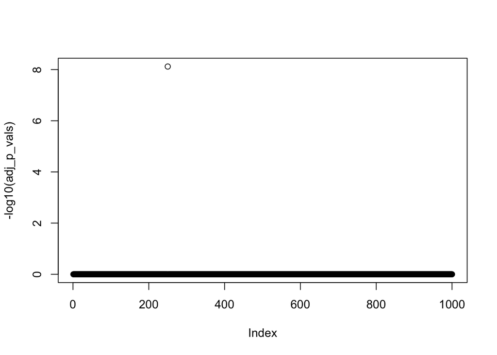

```r
plot(-log10(adj_p_vals))
```

You should see a single SNP showing a strong association with disease status.

# Negative Binomial and Poisson Regression

Molecular biologists study the behavior of protein expression in normal and cancerous tissues. The hypothesis is that the total number of over-expressed proteins depends on the histopathological-derived tumor subtype and an immune cell contexture measure.

You are provided with data on 314 tumours in the file `nb_data.Rdata`. The response variable of interest is `overexpressed_proteins`. The variable `immunoscore` gives a standardized measure of immune cell contexture. The variable `tumor_subtype` is a three-level nominal variable indicating the histopathological sub-type of the tumour.

Let’s load some prerequisite R libraries and the data to produce some summary statistics:

```r
library(MASS) # you need this library
library(foreign) # you need this library
load("nb_data.Rdata")
summary(dat)
```

```
##    sample_id      gender     immunoscore    overexpressed_proteins
##  1001   :  1   female:160   Min.   : 1.00   Min.   : 0.000
##  1002   :  1   male  :154   1st Qu.:28.00   1st Qu.: 1.000
##  1003   :  1                Median :48.00   Median : 4.000
##  1004   :  1                Mean   :48.27   Mean   : 5.955
##  1005   :  1                3rd Qu.:70.00   3rd Qu.: 8.000
##  1006   :  1                Max.   :99.00   Max.   :35.000
##  (Other):308
##   tumor_subtype
##  Complex : 40
##  Unstable:167
##  Stable  :107
##
##
##
##
```

Install the libraries using the following if you don’t have them:

```r
install.packages("MASS")
install.packages("foreign")
```

## Count-based GLMs

The `overexpressed_proteins` measurements are counts. This implies we should use a Poisson based GLM.

In Poisson regression models, the conditional variance is by definition equal to the conditional mean. This can be limiting.

Negative binomial regression can be used for over-dispersed count data, that is when the conditional variance exceeds the conditional mean.

In the following we will try both models to see which fits best.

## Fitting a GLM

Below we use the `glm.nb` function from the `MASS` package to estimate a negative binomial regression. The use of the function is similar to that of `lm` for linear models but with the additional requirement of a link function. As count data is always positive, a log link function is useful here.

```r
m1 <- glm.nb(overexpressed_proteins ~ immunoscore + tumor_subtype + gender, data = dat, link=log)
summary(m1)
```

```
##
## Call:
## glm.nb(formula = overexpressed_proteins ~ immunoscore + tumor_subtype +
##     gender, data = dat, link = log, init.theta = 1.047288915)
##
## Deviance Residuals:
##     Min       1Q   Median       3Q      Max
## -2.1567  -1.0761  -0.3810   0.2856   2.7235
##
## Coefficients:
##                        Estimate Std. Error z value Pr(>|z|)
## (Intercept)            2.707484   0.204275  13.254  < 2e-16 ***
## immunoscore           -0.006236   0.002492  -2.502   0.0124 *
## tumor_subtypeUnstable -0.424540   0.181725  -2.336   0.0195 *
## tumor_subtypeStable   -1.252615   0.199699  -6.273 3.55e-10 ***
## gendermale            -0.211086   0.121989  -1.730   0.0836 .
## ---
## Signif. codes:  0 '***' 0.001 '**' 0.01 '*' 0.05 '.' 0.1 ' ' 1
##
## (Dispersion parameter for Negative Binomial(1.0473) family taken to be 1)
##
##     Null deviance: 431.67  on 313  degrees of freedom
## Residual deviance: 358.87  on 309  degrees of freedom
## AIC: 1740.3
##
## Number of Fisher Scoring iterations: 1
##
##
##               Theta:  1.047
##           Std. Err.:  0.108
##
##  2 x log-likelihood:  -1728.307
```

R first displays the call and the deviance residuals. Next, we see the regression coefficients for each of the variables, along with standard errors, z-scores, and p-values. The variable `immunoscore` has a coefficient of -0.006, which is statistically significant. This means that for each one-unit increase in `immunoscore`, the expected log count of the number of `overexpressed_protein`s decreases by 0.006.

The indicator variable shown as `tumor_subtypeUnstable` is the expected difference in log count between group Unstable and the reference group (`tumor_subtype=Complex`). The expected log count for the Unstable type is approximately 0.4 lower than the expected log count for the `Complex` type.

The indicator variable for `Stable` type is the expected difference in log count between the `Stable` type and the reference `Complex` group.The expected log count for `Stable` is approximately 1.2 lower than the expected log count for the `Complex` type.

## Comparing nested models

To determine if `tumor_subtype` itself, overall, is statistically significant, we can compare a model with and without `tumor_subtype`. The reason it is important to fit separate models, is that unless we do, the overdispersion parameter is held constant.

```r
m2 <- glm.nb(overexpressed_proteins ~ immunoscore + gender, data = dat, link=log)
```

We use the `anova` function to compare models using a likelihood ratio test:

```r
anova(m1, m2, test="LRT")
```

```
## Likelihood ratio tests of Negative Binomial Models
##
## Response: overexpressed_proteins
##                                  Model     theta Resid. df    2 x log-lik.
## 1                 immunoscore + gender 0.8705939       311       -1772.074
## 2 immunoscore + tumor_subtype + gender 1.0472889       309       -1728.307
##     Test    df LR stat.      Pr(Chi)
## 1
## 2 1 vs 2     2 43.76737 3.133546e-10
```

The two degree-of-freedom chi-square test indicates that `tumor_subtype` is a statistically significant predictor of overexpressed_proteins

The `anova` function performs a form of *likelihood ratio test* (LRT). It computes the likelihood of the data under the two models being compared and then uses the ratio of these likelihood values as a test statistic.

Theory tells us that for large samples sizes, the two times the log likelihood ratio has a chi-squared distribution with degrees of freedom equal to the difference in the number of free parameters between the two models being compared. The LRT only applies to *nested models*, i.e. a pair of models where one is a less complex subset of the other.

## Negative-Binomial vs Poisson GLMs

Negative binomial models assume the conditional means are not equal to the conditional variances. This inequality is captured by estimating a dispersion parameter (not shown in the output) that is held constant in a Poisson model. Thus, the Poisson model is actually nested in the negative binomial model. We can then use a likelihood ratio test to compare these two models. To do this, we will first fit a GLM Poisson regression:

```r
m3 <- glm(overexpressed_proteins ~ immunoscore + tumor_subtype + gender, family = "poisson", data = dat)
```

Now, lets do our likelihood ratio test, we can extract the log-likelihood using `logLik` and then use `pchisq` to extract the probability of getting a statistic at least as extreme as this:

```r
print(pchisq(2 * (logLik(m1) - logLik(m3)), df = 1, lower.tail = FALSE)) # log likelihood ratio test
```

```
## 'log Lik.' 3.847622e-198 (df=6)
```

Note that the more complex model goes first.

In this example the associated chi-squared value estimated from `2*(logLik(m1) – logLik(m3))` is around 900 with one degree of freedom. This strongly suggests the negative binomial model, estimating the dispersion parameter, is more appropriate than the Poisson model.

## Further understanding the model

For assistance in further understanding the model, we can look at predicted counts for various levels of our predictors. Below we create new datasets with values of `immunoscore` and `tumor_subtype` and then use the `predict` command to calculate the predicted number of overexpressed proteins

First, we can look at predicted counts for each value of `tumor_subtype` while holding `immunoscore` at its mean. To do this, we create a new dataset with the combinations of `tumor_subtype` and `immunoscore` for which we would like to find predicted values, then use the `predict` command.

```r
newdata1 <- data.frame(immunoscore = mean(dat$immunoscore), tumor_subtype = factor(c("Complex", "Unstable", "Stable"), labels = levels(dat$tumor_subtype)), gender="male")
newdata2 <- data.frame(immunoscore = mean(dat$immunoscore), tumor_subtype = factor(c("Complex", "Unstable", "Stable"), labels = levels(dat$tumor_subtype)), gender="female")

newdata = rbind(newdata1, newdata2)

newdata$phat <- predict(m1, newdata, type = "response")
```

```r
newdata3 <- data.frame(immunoscore = rep(seq(from = min(dat$immunoscore), to = max(dat$immunoscore), length.out = 100), 3), tumor_subtype = rep(factor(c("Complex", "Unstable", "Stable"), labels = levels(dat$tumor_subtype)), each=100), gender="male")

newdata4 <- data.frame(immunoscore = rep(seq(from = min(dat$immunoscore), to = max(dat$immunoscore), length.out = 100), 3), tumor_subtype = rep(factor(c("Complex", "Unstable", "Stable"), labels = levels(dat$tumor_subtype)), each=100), gender="female")

newdata = newdata3

newdata <- cbind(newdata, predict(m1, newdata, type = "link", se.fit=TRUE))
newdata <- within(newdata, {
  overexpressed_proteins <- exp(fit)
  LL <- exp(fit - 1.96 * se.fit)
  UL <- exp(fit + 1.96 * se.fit)
})
```

Lets plot the result using `ggplot`:

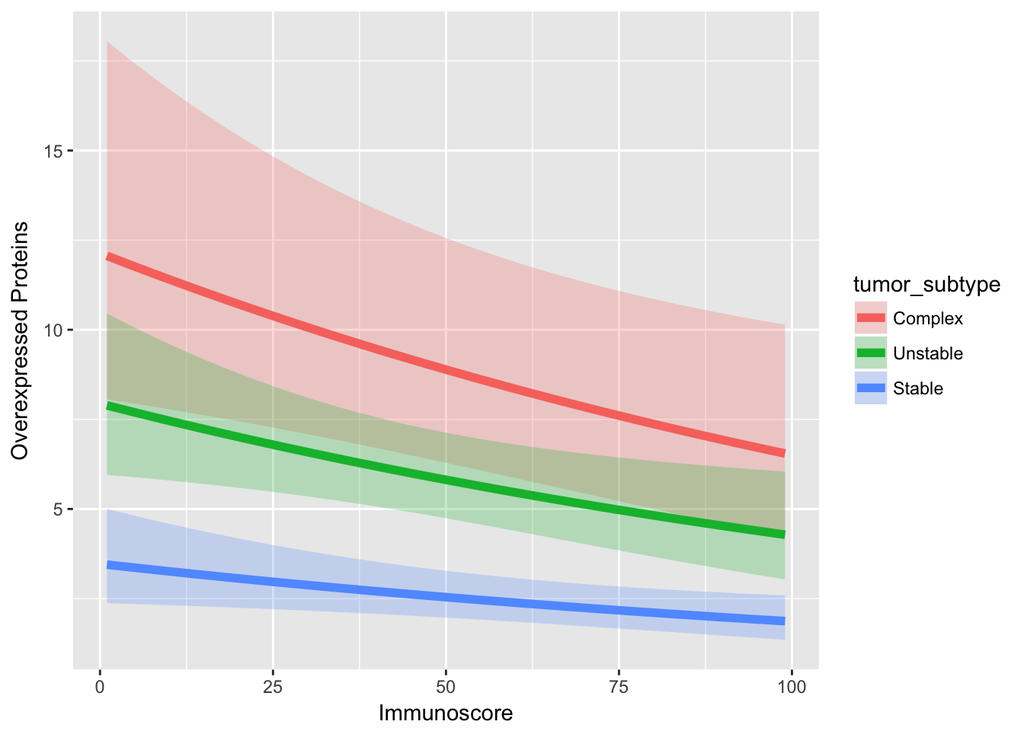

```r
library(ggplot2)

plt <- ggplot(newdata, aes(immunoscore, overexpressed_proteins)) +
  geom_ribbon(aes(ymin = LL, ymax = UL, fill = tumor_subtype), alpha = .25) +
  geom_line(aes(colour = tumor_subtype), size = 2) +
  labs(x = "Immunoscore", y = "Overexpressed Proteins")

print(plt)
```